# CMTH 642 Data Analytics: Advanced Methods

# Assignment 1 (10%)

#### 1. Read the csv files in the folder. (4 points)

```r
macro<-read.csv("C:/Users/Marco/Documents/CMTH 642/Assignment 1/USDA_Macronutrients.csv",header= T)
micro<-read.csv("C:/Users/Marco/Documents/CMTH 642/Assignment 1/USDA_Micronutrients.csv",header= T)
```

#### 2. Merge the data frames using the variable “ID”. Name the Merged Data Frame “USDA”. (4 points)

```r
df<-merge(macro,micro, by = "ID")
```

#### 3. Check the datatypes of the attributes. Delete the commas in the Sodium and Potasium records. Assign Sodium and Potasium as numeric data types. (4 points)

```r
df$Sodium = gsub(",", "", df$Sodium)
df$Potassium = gsub(",", "", df$Potassium)
df$Sodium = as.numeric(df$Sodium)
df$Potassium = as.numeric(df$Potassium)
```

#### 4. Remove records (rows) with missing values in more than 4 attributes (columns). How many records remain in the data frame? (4 points)

```r
summary(df)
```

```
##        ID        Description           Calories        Protein
##  Min.   : 1001   Length:7057        Min.   :  0.0   Min.   : 0.00
##  1st Qu.: 8387   Class :character   1st Qu.: 85.0   1st Qu.: 2.29
##  Median :13293   Mode  :character   Median :181.0   Median : 8.20
##  Mean   :14258                      Mean   :219.7   Mean   :11.71
##  3rd Qu.:18336                      3rd Qu.:331.0   3rd Qu.:20.43
##  Max.   :93600                      Max.   :902.0   Max.   :88.32
##
##     TotalFat       Carbohydrate        Sodium         Cholesterol
##  Min.   :  0.00   Min.   :  0.00   Min.   :    0.0   Min.   :   0.00
##  1st Qu.:  0.72   1st Qu.:  0.00   1st Qu.:   37.0   1st Qu.:   0.00
##  Median :  4.37   Median :  7.13   Median :   79.0   Median :   3.00
##  Mean   : 10.32   Mean   : 20.70   Mean   :  322.1   Mean   :  41.55
##  3rd Qu.: 12.70   3rd Qu.: 28.17   3rd Qu.:  386.0   3rd Qu.:  69.00
##  Max.   :100.00   Max.   :100.00   Max.   :38758.0   Max.   :3100.00
##                                    NA's   :83        NA's   :287
##      Sugar           Calcium             Iron           Potassium
##  Min.   : 0.000   Min.   :   0.00   Min.   :  0.000   Min.   :    0.0
##  1st Qu.: 0.000   1st Qu.:   9.00   1st Qu.:  0.520   1st Qu.:  135.0
##  Median : 1.395   Median :  19.00   Median :  1.330   Median :  250.0
##  Mean   : 8.257   Mean   :  73.53   Mean   :  2.828   Mean   :  301.4
##  3rd Qu.: 7.875   3rd Qu.:  56.00   3rd Qu.:  2.620   3rd Qu.:  348.0
##  Max.   :99.800   Max.   :7364.00   Max.   :123.600   Max.   :16500.0
##  NA's   :1909     NA's   :135       NA's   :122       NA's   :408
##     VitaminC           VitaminE          VitaminD
##  Min.   :   0.000   Min.   :  0.000   Min.   :  0.0000
##  1st Qu.:   0.000   1st Qu.:  0.120   1st Qu.:  0.0000
##  Median :   0.000   Median :  0.270   Median :  0.0000
##  Mean   :   9.436   Mean   :  1.488   Mean   :  0.5769
##  3rd Qu.:   3.100   3rd Qu.:  0.710   3rd Qu.:  0.1000
##  Max.   :2400.000   Max.   :149.400   Max.   :250.0000
##  NA's   :331        NA's   :2719      NA's   :2833
```

```r
CountNA=apply(is.na(df),1,sum)
df=df[CountNA<5,]
nrow(df) #remaining rows
```

```
## [1] 6887
```

#### 5. For records with missing values for Sugar, Vitamin E and Vitamin D, replace missing values with mean value for the respective variable. (4 points)

```r
df$Sugar[is.na(df$Sugar)] = mean(df$Sugar[!is.na(df$Sugar)])
df$VitaminE[is.na(df$VitaminE)] = mean(df$VitaminE[!is.na(df$VitaminE)])
df$VitaminD[is.na(df$VitaminD)] = mean(df$VitaminD[!is.na(df$VitaminD)])
```

#### 6. With a single line of code, remove all remaining records with missing values. Name the new Data Frame “USDAclean”. How many records remain in the data frame? (5 points)

```r
USDAclean=df[complete.cases(df),]
nrow(USDAclean)
```

```
## [1] 6310
```

#### 7. Which food has the highest sodium level? (5 points)

```r
USDAclean$Description[which.max(USDAclean$Sodium)]
```

```
## [1] "SALT,TABLE"
```

#### 8. Create a histogram of Vitamin C distribution in foods. (5 points)

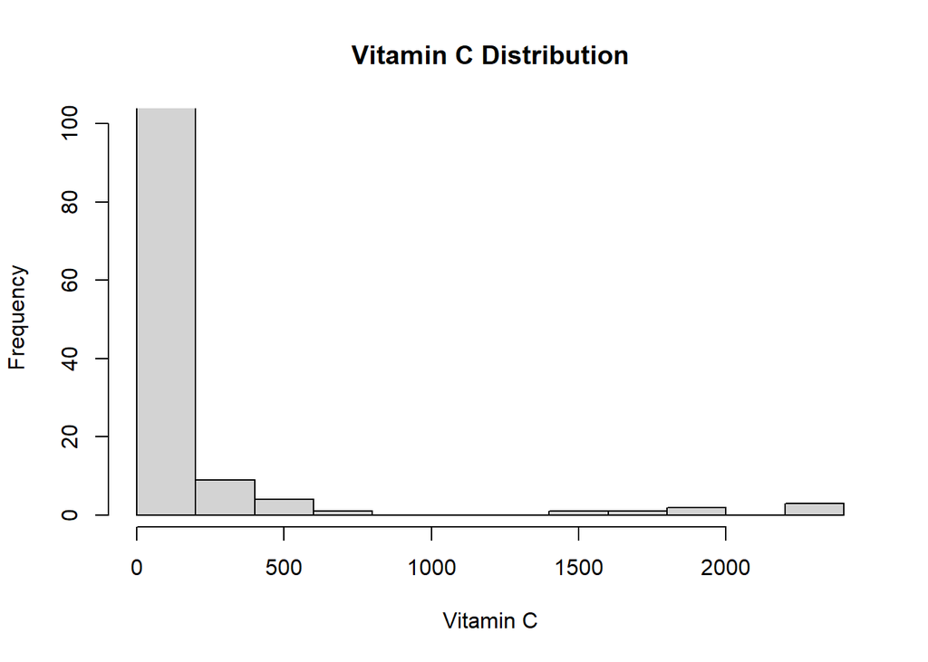

```r
hist(USDAclean$VitaminC, ylim=range(1,100),xlab = paste("Vitamin C"),main = paste("Vitamin C Distribution"))
```

#### 9. Create a boxplot to illustrate the distribution of values for TotalFat, Protein and Carbohydrate. (5 points)

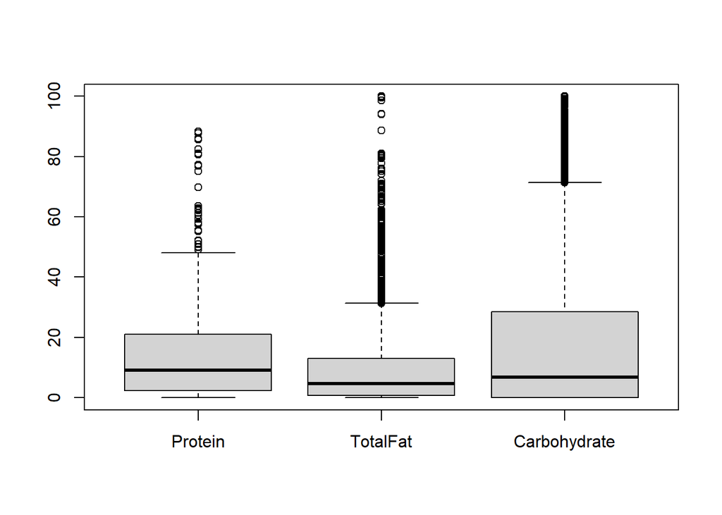

```r
boxplot(USDAclean[4:6])
```

#### 10. Create a scatterplot to illustrate the relationship between a food’s TotalFat content and its Calorie content. (5 points)

```r
library(ggvis)
USDAclean %>% ggvis(x = ~TotalFat, y = ~Calories) %>% layer_points()
```

[output not shown]

#### 11. Add a variable to the data frame that takes value 1 if the food has higher sodium than average, 0 otherwise. Call this variable HighSodium. Do the same for High Calories, High Protein, High Sugar, and High Fat. How many foods have both high sodium and high fat? (5 points)

```r
USDAclean$HighSodium[USDAclean$Sodium > mean(USDAclean$Sodium)] <- 1
USDAclean$HighSodium[USDAclean$Sodium <= mean(USDAclean$Sodium)] <- 0

USDAclean$HighCalories[USDAclean$Calories > mean(USDAclean$Calories)] <- 1
USDAclean$HighCalories[USDAclean$Calories <= mean(USDAclean$Calories)] <- 0

USDAclean$HighProtein[USDAclean$Protein > mean(USDAclean$Protein)] <- 1
USDAclean$HighProtein[USDAclean$Protein <= mean(USDAclean$Protein)] <- 0

USDAclean$HighSugar[USDAclean$Sugar > mean(USDAclean$Sugar)] <- 1
USDAclean$HighSugar[USDAclean$Sugar <= mean(USDAclean$Sugar)] <- 0

USDAclean$HighFat[USDAclean$TotalFat > mean(USDAclean$TotalFat)] <- 1
USDAclean$HighFat[USDAclean$TotalFat <= mean(USDAclean$TotalFat)] <- 0


cat(sum(apply(USDAclean[c("HighSodium", "HighFat")], 1, function(x) sum(x) == 2)))
```

```
## 644
```

#### 12. Calculate the average amount of iron, for high and low protein foods. (5 points)

```r
MeanProteinIron <- aggregate(USDAclean$Iron,list(USDAclean$HighProtein),FUN = mean)
colnames(MeanProteinIron) <- c("low/high protein","AVG")
head(MeanProteinIron)
```

```
##   low/high protein      AVG
## 1                0 2.696634
## 2                1 3.069541
```

#### 13. Create a function for a “HealthCheck” program to detect unhealthy foods. Use the algorithm flowchart below as a basis. (5 points)

```r
require(jpeg)
```

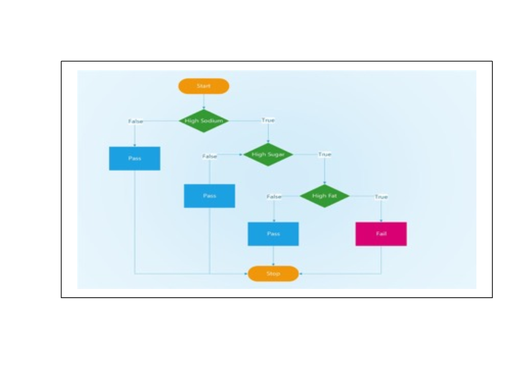

```r
img<-readJPEG("HealthCheck.jpg")
plot(1:4, ty = 'n', ann = F, xaxt = 'n', yaxt = 'n')
rasterImage(img,1,1,4,4)
```

```r
HealthCheck <- function (sodium,sugar,fat) {
  ifelse (sodium==0, "Pass", ifelse (sugar==0, "Pass", ifelse (fat==0, "Pass", "Fail")))
}
```